# Data Visualization

## Recap

- `pivot_longer()` helps us take our data from wide to long format
  - `names_to =` gives a new name to the pivoted columns
  - `values_to =` gives a new name to the values that used to be in those columns
- `pivot_wider()` helps us take our data from long to wide format
  - `names_from` specifies the old column name that contains the new column names
  - `values_from` specifies the old column name that contains new cell values
- to merge/join data sets together need a variable in common - usually “id”

📃[Cheatsheet](https://jhudatascience.org/intro_to_r/modules/cheatsheets/Day-6.pdf)

## Recap continued

- to merge/join data sets together need a variable in common - usually “id”
- `?join` - see different types of joining for `dplyr`
- `inner_join(x, y)` - only rows that match for `x` and `y` are kept
- `full_join(x, y)` - all rows of `x` and `y` are kept
- `left_join(x, y)` - all rows of `x` are kept even if not merged with `y`
- `right_join(x, y)` - all rows of `y` are kept even if not merged with `x`
- `anti_join(x, y)` - all rows from `x` not in `y` keeping just columns from `x`.
- `esquisser()` function of the `esquisse` package can help make plot sketches

📃[Cheatsheet](https://jhudatascience.org/intro_to_r/modules/cheatsheets/Day-6.pdf)

## `esquisse` and `ggplot2`

[figure not shown]

## Why learn ggplot2?

More customization:

- branding
- making plots interactive
- combining plots

Easier plot automation (creating plots in scripts)

Faster (eventually)

## ggplot2

- A package for producing graphics - gg = *Grammar of Graphics*
- Created by Hadley Wickham in 2005
- Belongs to “Tidyverse” family of packages
- *“Make a ggplot”* = Make a plot with the use of ggplot2 package

Resources:

- https://ggplot2-book.org/
- https://www.opencasestudies.org/

## ggplot2

Based on the idea of:

layering

plot objects are placed on top of each other with `+`

📉 +  
📈

## ggplot2

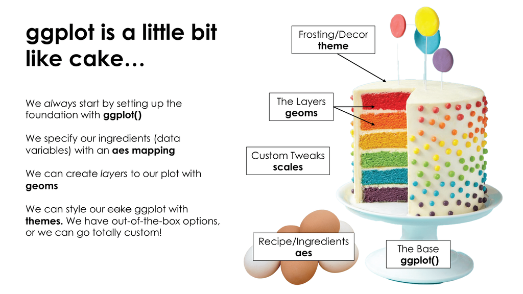

Slide Credit: Tanya Shapiro

## ggplot2

- Pros: extremely powerful/flexible – allows combining multiple plot elements together, allows high customization of a look, many resources online
- Cons: ggplot2-specific “grammar of graphic” of constructing a plot
- [ggplot2 gallery](https://www.r-graph-gallery.com/ggplot2-package.html)

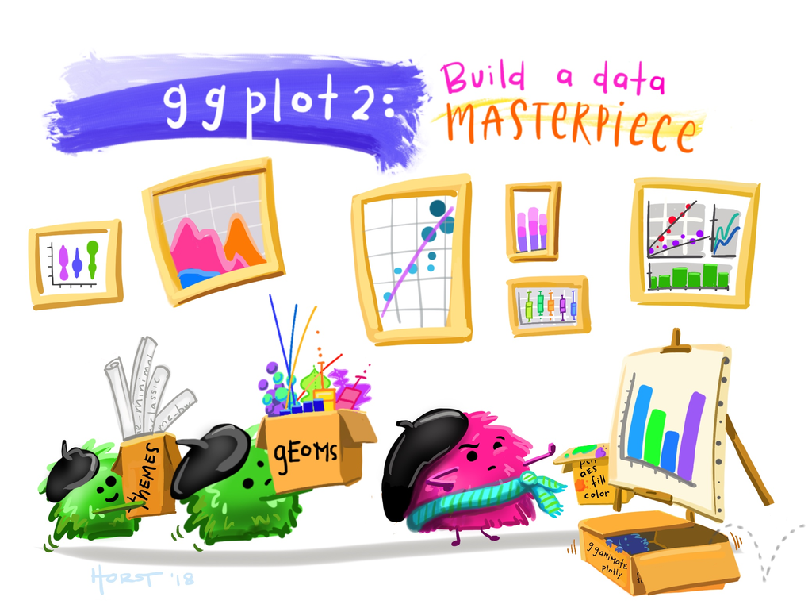

Artwork by @allison_horst. https://allisonhorst.com/

## Tidy data

To make graphics using `ggplot2`, our data needs to be in a **tidy** format

**Tidy data**:

1. Each variable forms a column.
2. Each observation forms a row.

Messy data:

- Column headers are values, not variable names.
- Multiple variables are stored in one column.
- Variables are stored in both rows and columns.

## Tidy data: example

Ideally we want each variable as a column and we want each observation in a row.

Column headers are values, not variable names:

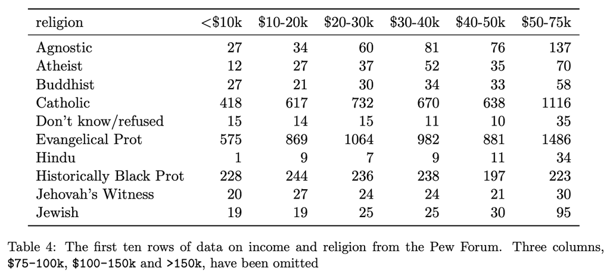

## Now the the data is “tidy” and in long format

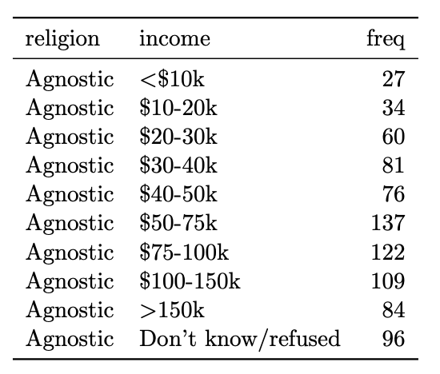

Read more about tidy data and see other examples: [Tidy Data](https://vita.had.co.nz/papers/tidy-data.pdf) tutorial

## Data to plot

Type `?Orange` for more information.

Is the data in tidy? Is it in long format?

```r
head(Orange)
```

```
  Tree  age circumference
1    1  118            30
2    1  484            58
3    1  664            87
4    1 1004           115
5    1 1231           120
6    1 1372           142
```

## First plot with `ggplot2` package

## First layer of code with `ggplot2` package

Will set up the plot - it will be empty!

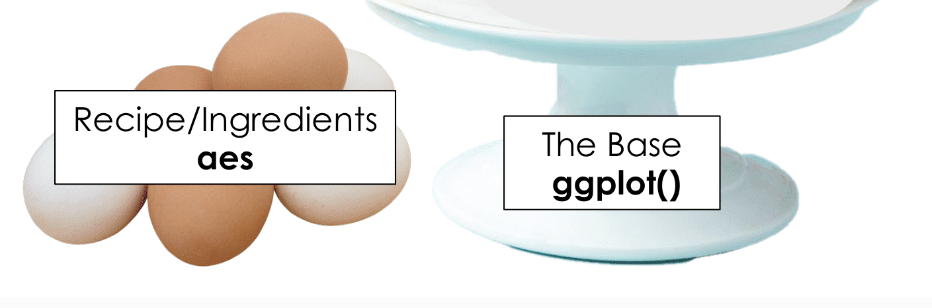

## First layer of code with `ggplot2` package

- **Aesthetic mapping** `aes(x= , y =)` describes how variables in our data are mapped to elements of the plot - Note you don’t need to use `mapping` but it is helpful to know what we are doing.

```r
library(tidyverse) # don't forget to load ggplot2 (part of tidyverse)
# This is not code but shows the general format
ggplot({data_to plot}, aes(x = {var in data to plot},
                                      y = {var in data to plot}))
```

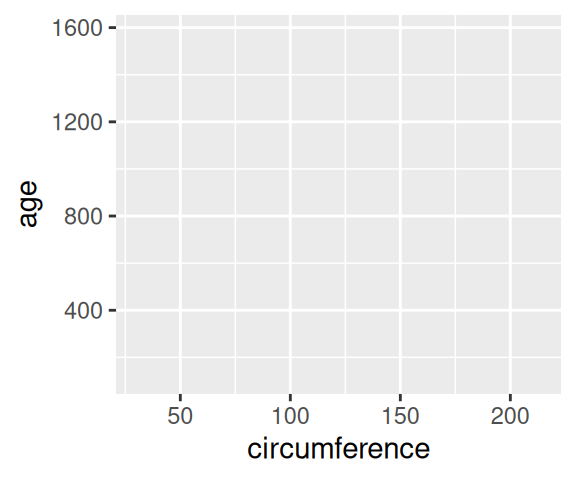

```r
ggplot(Orange, aes(x = circumference, y = age))
```